# Tooth Growth - Statistical Inference Part 2

Jackie Milhans

July 24, 2015

We’re going to analyze the ToothGrowth data in the R datasets package. Load the ToothGrowth data and perform some basic exploratory data analyses.

## Data Summary

The ToothGrowth dataset is the response is the length of odontoblasts (teeth) in each of 10 guinea pigs at each of three dose levels of Vitamin C (0.5, 1, and 2 mg) with each of two delivery methods (orange juice or ascorbic acid).

Let’s provide a basic summary of the data. First we load the dataset.

```r
library(datasets)
data(ToothGrowth)
head(ToothGrowth)
```

```
##    len supp dose
## 1  4.2   VC  0.5
## 2 11.5   VC  0.5
## 3  7.3   VC  0.5
## 4  5.8   VC  0.5
## 5  6.4   VC  0.5
## 6 10.0   VC  0.5
```

```r
summary(ToothGrowth)
```

```
##       len        supp         dose
##  Min.   : 4.20   OJ:30   Min.   :0.500
##  1st Qu.:13.07   VC:30   1st Qu.:0.500
##  Median :19.25           Median :1.000
##  Mean   :18.81           Mean   :1.167
##  3rd Qu.:25.27           3rd Qu.:2.000
##  Max.   :33.90           Max.   :2.000
```

The summary of the dataset shows that there are two supplements, OJ and VC. There are 3 doses: 0.5, 1, and 2.

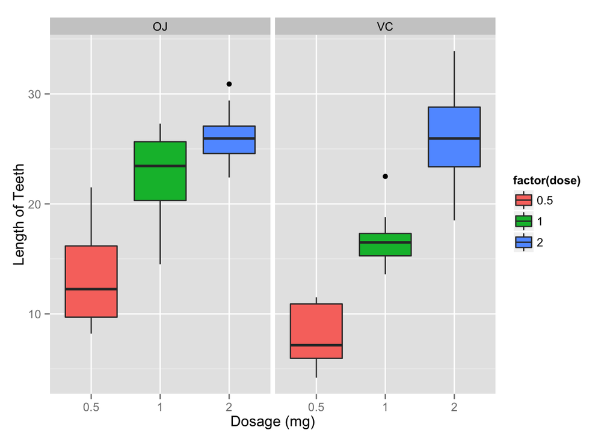

```r
library(ggplot2)
ggplot(ToothGrowth, aes(x=factor(dose), y=len, fill=factor(dose))) +
        geom_boxplot() +
        facet_grid(.~supp) +
        labs(main="Analyzing ToothGrowth Dataset", y="Length of Teeth", x="Dosage (mg)")
```

The plots show that a high dosage leads to longer teeth.

## Confidence Intervals

We use confidence intervals and/or hypothesis tests to compare tooth growth by supp and dose.

Here, we use the hypothesis test, t-test.

We can also look at the data by splitting into the different dosages.

```r
dose1 <- subset(ToothGrowth, dose==0.5)
dose2 <- subset(ToothGrowth, dose==1.0)
dose3 <- subset(ToothGrowth, dose==2.0)
```

First, we look at the smallest dose.

```r
t.test(len~supp, data=dose1, paired=FALSE)
```

```
##
##  Welch Two Sample t-test
##
## data:  len by supp
## t = 3.1697, df = 14.969, p-value = 0.006359
## alternative hypothesis: true difference in means is not equal to 0
## 95 percent confidence interval:
##  1.719057 8.780943
## sample estimates:
## mean in group OJ mean in group VC
##            13.23             7.98
```

Finally, the largest dose is examined.

```r
t.test(len~supp, data=dose3, paired=FALSE)
```

```
##
##  Welch Two Sample t-test
##
## data:  len by supp
## t = -0.046136, df = 14.04, p-value = 0.9639
## alternative hypothesis: true difference in means is not equal to 0
## 95 percent confidence interval:
##  -3.79807  3.63807
## sample estimates:
## mean in group OJ mean in group VC
##            26.06            26.14
```

## Conclusions

For the lower dosage data, we can see that the OJ produces higher tooth growth. At the highest dosage, there is little difference between the two supplements.

For a higher dose, the p-value is greater than 0.05, and the confidence interval lies between (-3.79807, 3.63807). The CI includes 0, so it shows that there is no significant difference between the two supplements.

For the smallest dosage, the p-value is lower that 0.05, and the confidence interval does not include 0. Therefore, we can see that there is a significant difference in growth with the smaller dose.

## APPENDIX

Here, we use the hypothesis test by supplement for all data, t-test.

```r
t.test(len~supp, data=ToothGrowth, paired=FALSE)
```

```
##
##  Welch Two Sample t-test
##
## data:  len by supp
## t = 1.9153, df = 55.309, p-value = 0.06063
## alternative hypothesis: true difference in means is not equal to 0
## 95 percent confidence interval:
##  -0.1710156  7.5710156
## sample estimates:
## mean in group OJ mean in group VC
##         20.66333         16.96333
```

Dosage of 1.0 mg.

```r
t.test(len~supp, data=dose2, paired=FALSE)
```

```
##
##  Welch Two Sample t-test
##
## data:  len by supp
## t = 4.0328, df = 15.358, p-value = 0.001038
## alternative hypothesis: true difference in means is not equal to 0
## 95 percent confidence interval:
##  2.802148 9.057852
## sample estimates:
## mean in group OJ mean in group VC
##            22.70            16.77
```